# Final Exam

2022-12-11

##Final Exam Data Retrieved from Kaggle, but originally from FiveThirtyEight https://www.kaggle.com/datasets/thedevastator/uncovering-insights-to-college-majors-and-their?select=all-ages.csv

This data set provides information on college majors and their employability, popularity, and salary.

#Inputting and Setting up Data/Packages z Q7

```r
mydata <- read.csv("C:\\Users\\bucol\\Desktop\\recent-grads.csv")
library(tidyverse)  # data manipulation
library(factoextra) # clustering algorithms & visualization
library(ISLR)
library(cluster)
library(flexclust)
#First I will modifying the data to turn the variables of interest into rates that are all positive in direction. We will be turning everything into a rate instead of normalizing.

newdata <- mydata
newdata$Employmen_rate <- mydata$Employed / mydata$Total # This is the postive version of unemployment rate
newdata$College_Jobs_Rate <- mydata$College_jobs / mydata$Total #This is the rate of college jobs
newdata$NonLow_Wage_jobs_Rate <- (mydata$Total - mydata$Low_wage_jobs) / mydata$Total #This is the rate of non low jwage
newdata$Median <- mydata$Median / 110000 #this turns the median salary into a rate where we're using the highest salary as the divisor

#Then I will be removing several variables due to redundancy.
#to do this I will create a list of variables.

myvars <- c("Employmen_rate","Median","College_Jobs_Rate", "NonLow_Wage_jobs_Rate")
#This is the selection of variables I will use to provide some basic information about recent graduates.

majordata <- newdata[,myvars] #This is now selecting only those variables.
summary(majordata)
```

```
##  Employmen_rate       Median       College_Jobs_Rate NonLow_Wage_jobs_Rate
##  Min.   :0.0000   Min.   :0.2000   Min.   :0.0000    Min.   :0.6990
##  1st Qu.:0.7477   1st Qu.:0.3000   1st Qu.:0.2395    1st Qu.:0.8821
##  Median :0.8028   Median :0.3273   Median :0.3206    Median :0.9137
##  Mean   :0.7886   Mean   :0.3650   Mean   :0.3520    Mean   :0.9101
##  3rd Qu.:0.8410   3rd Qu.:0.4091   3rd Qu.:0.4630    3rd Qu.:0.9452
##  Max.   :0.9562   Max.   :1.0000   Max.   :0.7515    Max.   :1.0000
```

For this analysis we will consider the variables importance as seen below:

Highest: College Job Rate (This shows the rate of grads who got a job that uses their college level education) Medium: Non low wage jobs and Median Lowest: Employment rate

Due to this, we will weight each value as shown below:

College Jobs Rate: 3 Median: 1.5 NonLow Jobs Rate: 1.5 Employment Rate: 1

Instead of normalizing, we have created rates for each value. Now we will weight them.

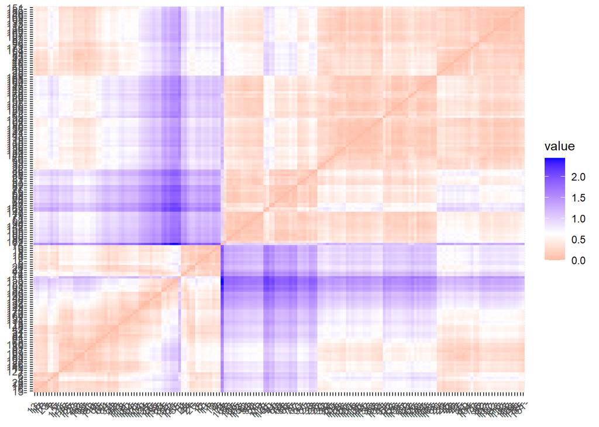

```r
weighteddata <- majordata
weighteddata$Median <- majordata$Median *1.5
weighteddata$NonLow_Wage_jobs_Rate <- majordata$NonLow_Wage_jobs_Rate *1.5
weighteddata$College_Jobs_Rate <- majordata$College_Jobs_Rate *3

distancedata <- get_dist(weighteddata)
fviz_dist(distancedata)
```

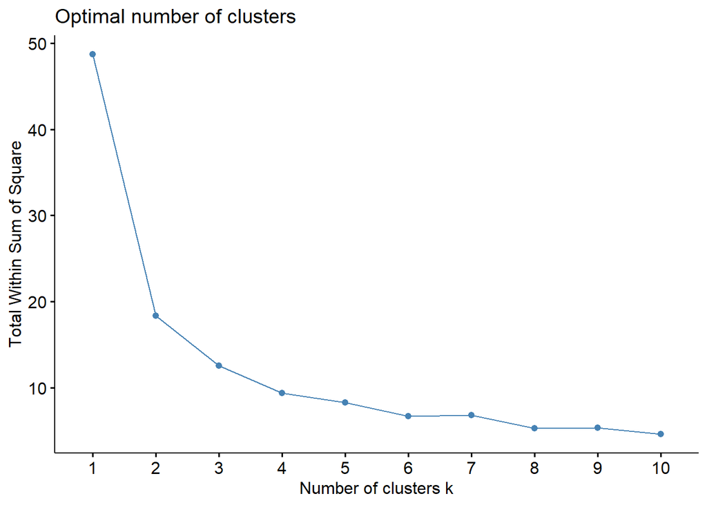

```r
fviz_nbclust(weighteddata, kmeans, method = "wss")
```

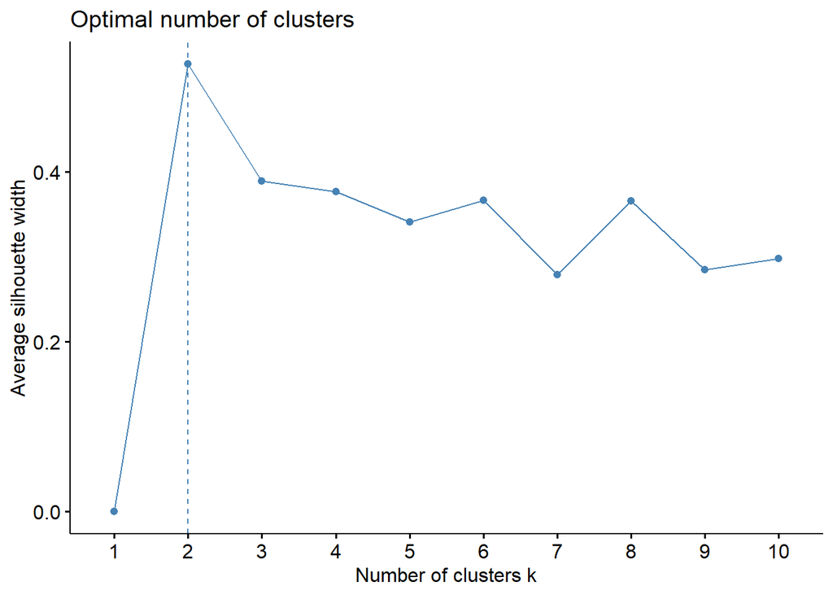

```r
#It seems our elbow point is 2, but its sort of hard to tell.
fviz_nbclust(weighteddata, kmeans, method = "silhouette")
```

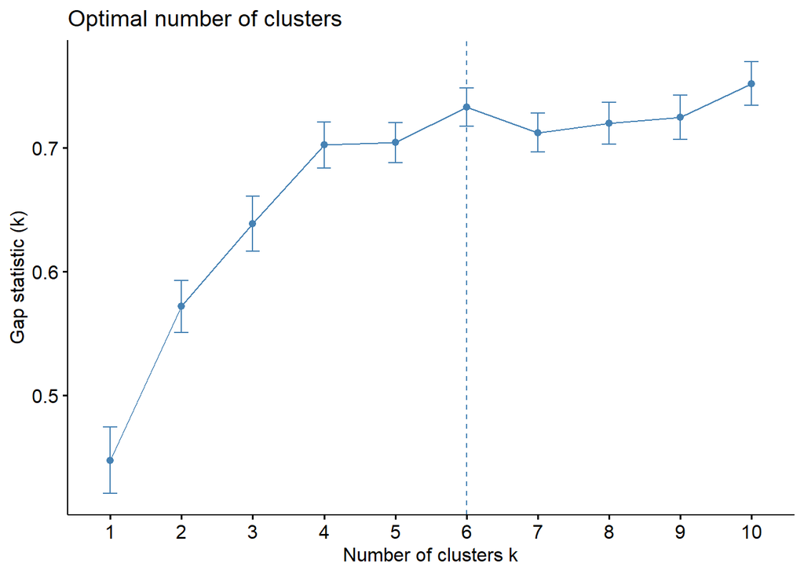

```r
#This method suggests 2 clusters.
gap_stat <- clusGap(weighteddata, FUN = kmeans, nstart = 25,
                    K.max = 10, B = 50)
fviz_gap_stat(gap_stat)
```

```r
#this method suggests 6 clusters.
```

#Now we cluster.

```r
set.seed(17)
cluster2 <- kmeans(weighteddata, centers = 2, nstart = 25)

#Let's Visualize
cluster2$centers
```

```
##   Employmen_rate    Median College_Jobs_Rate NonLow_Wage_jobs_Rate
## 1      0.7976003 0.6172521         1.5828310              1.408498
## 2      0.7830508 0.5045072         0.7311176              1.338445
```

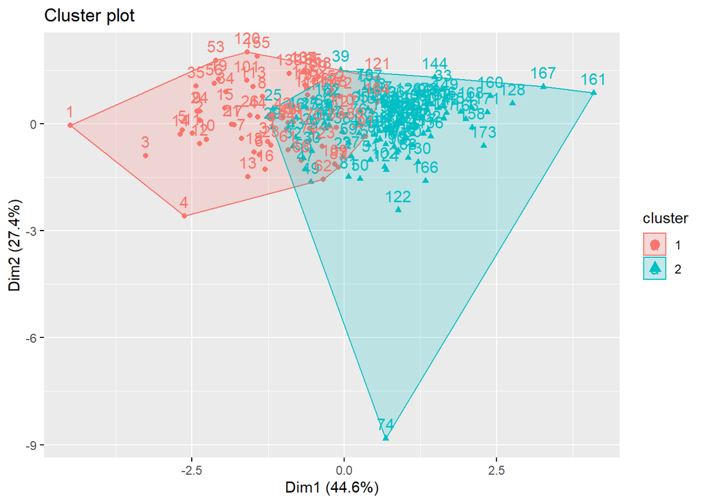

```r
fviz_cluster(cluster2, data= weighteddata)
```

```r
cluster2$size
```

```
## [1]  66 107
```

```r
#Visualizing this, we can see we have two cluster, but theres not a ton of information was can draw from this since the groups are so large. Lets break it up a bit more like the gap stat suggested.

cluster6 <- kmeans(weighteddata, centers = 6, nstart = 25)

#Let's Visualize
cluster6$centers
```

```
##   Employmen_rate    Median College_Jobs_Rate NonLow_Wage_jobs_Rate
## 1      0.8712344 0.5080519         1.9996020              1.414563
## 2      0.7955919 0.4862987         1.4765204              1.395364
## 3      0.7846626 0.4653896         0.8262767              1.328282
## 4      0.8072339 0.8582386         1.6696752              1.427569
## 5      0.7446263 0.6094135         1.1571663              1.390329
## 6      0.7880879 0.5345844         0.4239034              1.335512
```

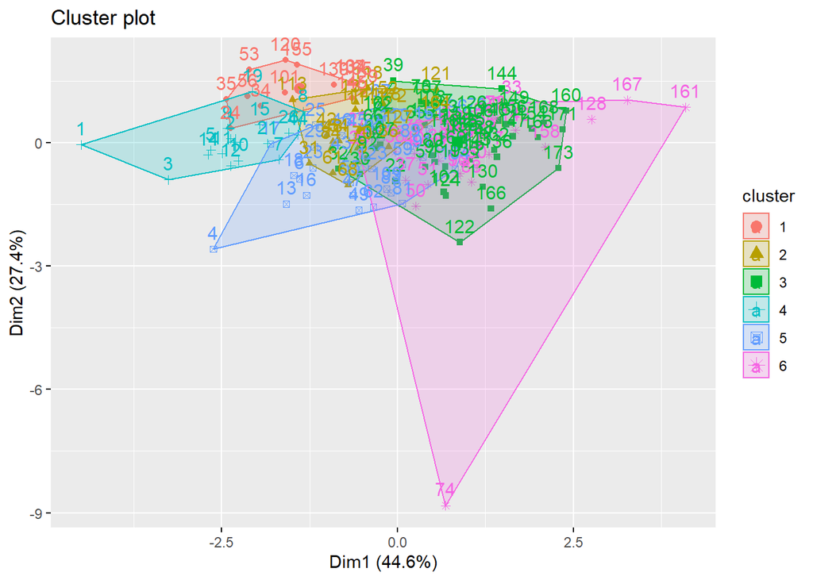

```r
fviz_cluster(cluster6, data= weighteddata)
```

```r
cluster6$size
```

```
## [1] 14 21 56 16 31 35
```

Here we can see the first cluster has two groups. Group 1 has 66 majors Group 2 has 107.

Due to the nature of the problem, I will be utilizing the 6 clusters for the analysis.

```r
cluster6dataA <- cluster6$cluster
cluster6dataB <- cbind(newdata, cluster6dataA) #this adds our kmeans clusters for 6 clusters to the dataset
c2vars <- c("Major","Major_category", "Total","ShareWomen", "Employmen_rate","Median","College_Jobs_Rate", "NonLow_Wage_jobs_Rate","cluster6dataA")
cluster6data <- cluster6dataB[,c2vars]

Group1 <- subset(cluster6data, cluster6dataA ==1) #this returns just the majors in the 1st cluster
Group2 <- subset(cluster6data, cluster6dataA == 2) #this returns just the majors in the 2nd cluster
Group3 <- subset(cluster6data, cluster6dataA == 3) #this returns just the majors in the 3rd cluster
Group4 <- subset(cluster6data, cluster6dataA == 4) #this returns just the majors in the 4th cluster
Group5 <- subset(cluster6data, cluster6dataA == 5) #this returns just the majors in the 5th cluster
Group6 <- subset(cluster6data, cluster6dataA == 6) #this returns just the majors in the 6th cluster

Group6
```

```
##                                                                 Major
## 27                                              CONSTRUCTION SERVICES
## 28                                OPERATIONS LOGISTICS AND E-COMMERCE
## 33                                            MISCELLANEOUS FINE ARTS
## 36                                                            FINANCE
## 37                                                          ECONOMICS
## 38                                                 BUSINESS ECONOMICS
## 40         NUCLEAR, INDUSTRIAL RADIOLOGY, AND BIOLOGICAL TECHNOLOGIES
## 41                                                         ACCOUNTING
## 50                                                       OCEANOGRAPHY
## 51                              ENGINEERING AND INDUSTRIAL MANAGEMENT
## 52                                         MEDICAL ASSISTING SERVICES
## 58                                                   GENERAL BUSINESS
## 60                                             INTERNATIONAL BUSINESS
## 63                    MISCELLANEOUS BUSINESS & MEDICAL ADMINISTRATION
```

[output cut: 93 more lines]